# Macroeconometrics Assignment 2 - Group 5 Report

Alex Rendell, Xinyu Dang, Gavin Williams

29/04/2022

### **Exercise 1 - Variable selection**

In this section, we (i) list and justify the selection of nine macroeconomic variables used to forecast ‘Hours Worked’, (ii) Source and transform the data for the ten variables into a data matrix, and (iii) Plot the data matrix and comment with observations.

**Selections**  
To forecast Hours worked (Index), we selected: - Household Savings Ratio (Proportion) - Total Unemployed persons (000s); - CPI Index Change (Percent change from previous period); - Real Unit Labour Costs (Index); - GDP Growth (Chain Volume Measure, Percentage change) - Secondary Household income(Social assistance benefits) received ($millions) - Inventories (Chain Volume Measure, $millions) - Disposable Income per Capita (Real net national disposable income per capita, $) - Terms of Trade (Percentage change from previous period)

All measures are at the national level, seasonally adjusted and measured quarterly for consistency of the analysis.

Unemployment and Real Unit Labour Costs relate to Hours worked through obvious labour supply and demand relationships between price of labour (wages) as well as the size of the workforce. Household savings, Secondary income (social benefits) and Disposable Income will relate to Labour Supply and hence Hours Worked as agents supply less labour when they can rely on greater savings/income.

We consider GDP Growth, Terms of Trade and Inventories to have a relationship with Hours Worked, as when the demand for goods, this will affect the demand for labour for production, and thus the number of hours supplied by employers. Similarly there will be a relationship between CPI (prices of household goods and services purchased) and labour demand and supply, with employers and employees making decisions based on their expenditures.

```r
# INSTALLING REQUIRED PACKAGES
rm(list=ls())
library(readrba)
library(readabs)
library(tidyr)
library(dplyr)
```

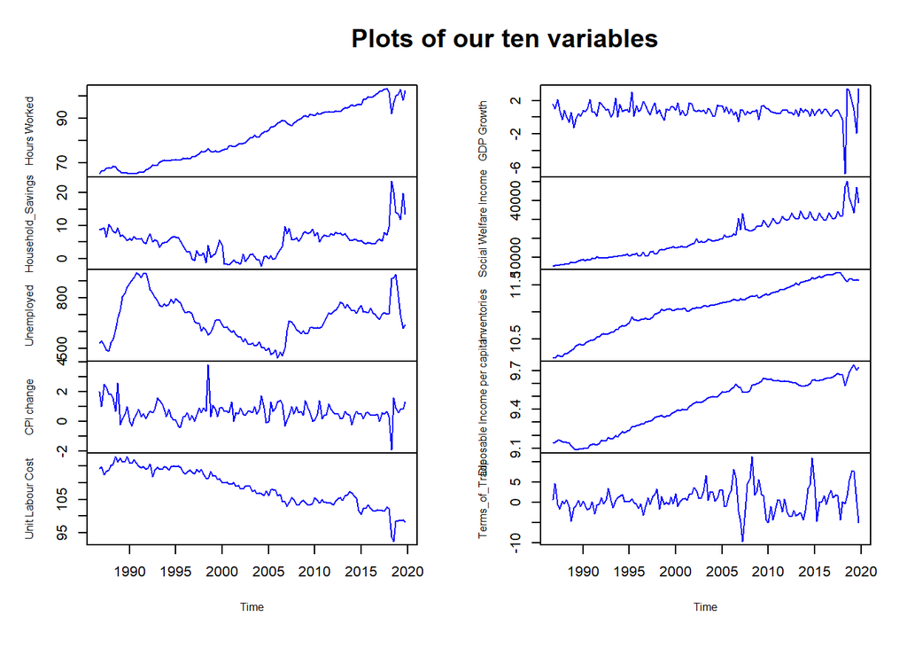

```r
library(knitr)
library(ggplot2)
library(lubridate)
library(reticulate)
library(mvtnorm)
library(HDInterval)
library(xtable)
library(tinytex)
set.seed(123456)


# DATA COLLECTION AND TRANSFORMING
##VAR1
HOURS               = read_abs(series_id ="A2304428W")
HOURS               = HOURS %>%slice(-c(1:101))
HOURS               = HOURS[c(4,6)]

##VAR2
HHSAVINGS           = read_abs(series_id = "A2323382F")
HHSAVINGS           = HHSAVINGS %>%slice(-c(1:101))
HHSAVINGS           = HHSAVINGS[c(4,6)]

##VAR3
UNEMPLOYMENT          = read_abs(series_id = "A2454521V")
UNEMPLOYMENT          = UNEMPLOYMENT %>%slice(-c(1:109))
UNEMPLOYMENT          = UNEMPLOYMENT[c(4,6)]

##VAR4
CPI_CHANGE_Q        = read_abs(series_id = "A2325850V")
CPI_CHANGE_Q        = CPI_CHANGE_Q %>%slice(-c(1:153))
CPI_CHANGE_Q        = CPI_CHANGE_Q[c(4,6)]

##VAR5
REAL_LABOUR_COST    = read_abs(series_id = "A2433071F")
REAL_LABOUR_COST    = REAL_LABOUR_COST %>%slice(-c(1:5))
REAL_LABOUR_COST    = REAL_LABOUR_COST[c(4,6)]

##VAR6
GDP_PCT_CHANGE      = read_abs(series_id = "A2304370T")
GDP_PCT_CHANGE      = GDP_PCT_CHANGE %>%slice(-c(1:101))
GDP_PCT_CHANGE      = GDP_PCT_CHANGE[c(4,6)]

##VAR7
HH_SOCIAL_BENEFITS  = read_abs(series_id = "A2454564V")
HH_SOCIAL_BENEFITS  = HH_SOCIAL_BENEFITS %>%slice(-c(1:109))
HH_SOCIAL_BENEFITS  = HH_SOCIAL_BENEFITS[c(4,6)]


##VAR8
INVENTORIES         = read_abs(series_id = "A2454511R")
INVENTORIES         = INVENTORIES %>%slice(-c(1:5))
INVENTORIES         = INVENTORIES[c(4,6)]
INVENTORIES$value   = log(INVENTORIES$value)


##VAR9
DISP_INC_PC         = read_abs(series_id = "A2304416L")
DISP_INC_PC         = DISP_INC_PC %>% slice(-c(1:101))
DISP_INC_PC         = DISP_INC_PC[c(4,6)]
DISP_INC_PC$value   = log(DISP_INC_PC$value)


##VAR10
TOT                 = read_abs(series_id = "A2304400V")
TOT                 = TOT %>% slice(-c(1:101))
TOT                 = TOT[c(4,6)]

# Create Y and X
############################################################
y_VEC1              = merge(HOURS, HHSAVINGS, by = 'date')
y_VEC2              = merge(UNEMPLOYMENT, CPI_CHANGE_Q, by = 'date')
y_VEC3              = merge(REAL_LABOUR_COST, GDP_PCT_CHANGE, by ='date')
y_VEC4              = merge(HH_SOCIAL_BENEFITS, INVENTORIES, by ='date')
y_VEC5              = merge(DISP_INC_PC, TOT, by ='date')

y1                  = merge(y_VEC1, y_VEC2, by = 'date')
y2                  = merge(y_VEC3, y_VEC4, by = 'date')
y3                  = merge(y1, y2, by ='date')

y                   = merge(y3, y_VEC5, by = 'date')
y                   = y %>% slice(-c(1:8))
y                   = ts(y[,c(2:11)], start = c(1986,4), frequency = 4, names=c(
                                        "Hours Worked","Household_Savings","Unemployed","CPI change",
                                        "Unit Labour Cost","GDP Growth","Social Welfare Income","Inventories",
                                        "Diposable Income per capita","Terms_of_Trade"))

#Plot macro data and comment on trends
plot(y, main = "Plots of our ten variables", cex.lab = 0.5, col = "blue")
```

**Observations**  
For many variables, we see an upward trend over time which follows Hours Worked (which has steadily increased over time). A trend is less obvious when considering variables which are percentage changes from the previous period. We also see a downward trend in real labour unit costs.

## **Exercise 2 - Likelihood function and joint prior distribution for parameter matrices**

In this section we document the likelihood function of the model, and the probability density function of A and $\Sigma$ which follows joint matrix-variate normal-inverse Wishart distribution, and includes two hyperparameters.

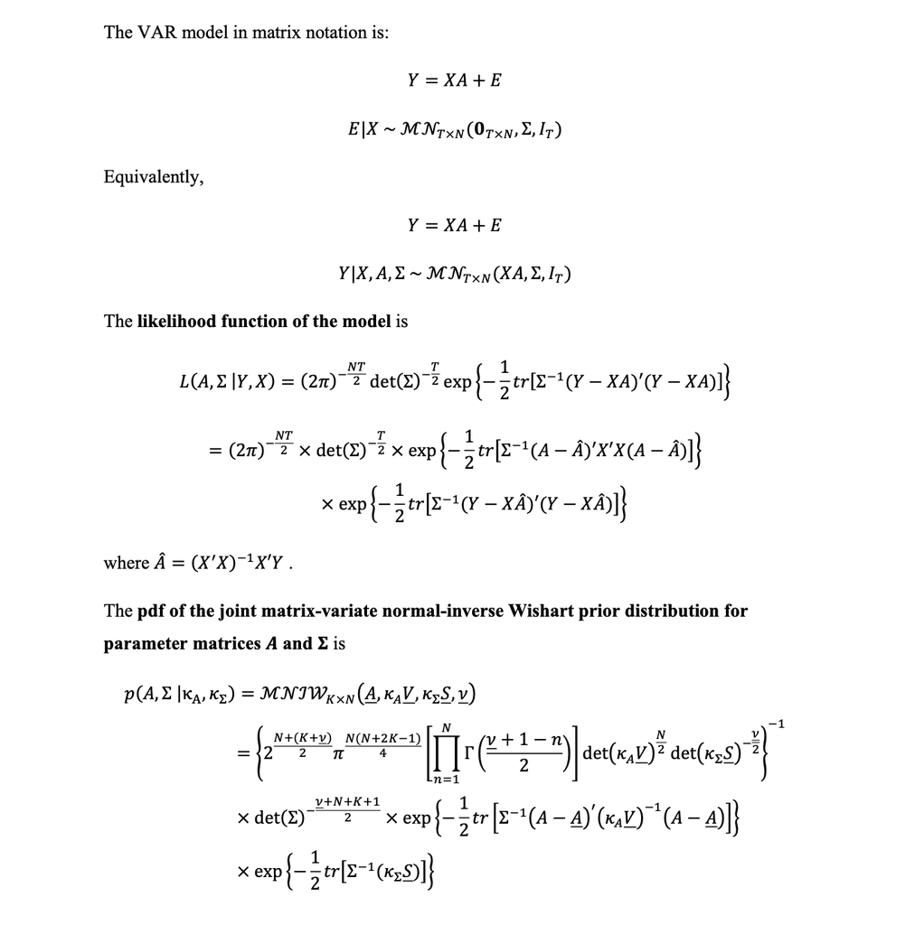

We also specify the parameters determining the prior distribution matrices

[figure not shown]

## **Exercise 3 - Joint conditional posterior distribution**

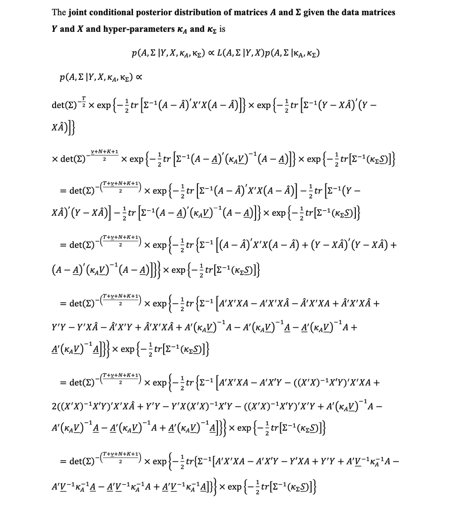

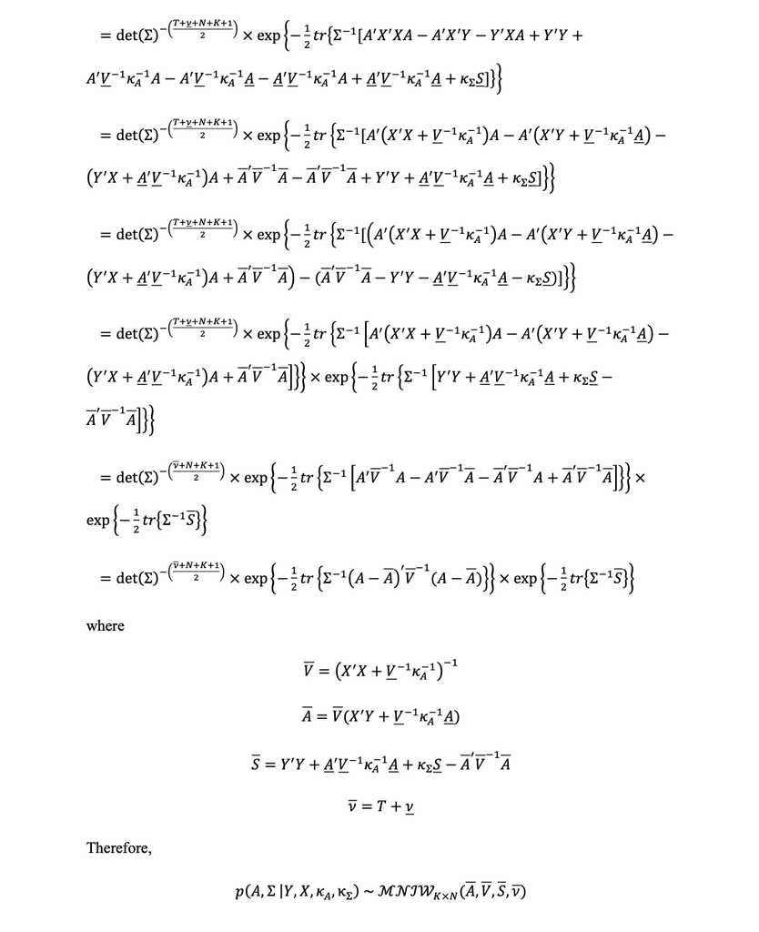

## **Exercise 4 - Conditionally conjugate prior distributions for hyper-parameters**

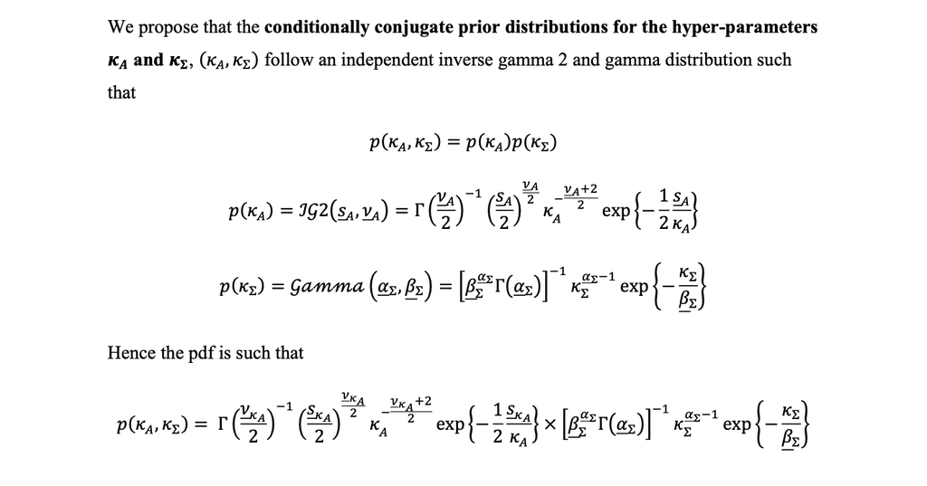

## **Exercise 5 – Deriving Full Condition Posterior Distributions for the hyper-parameters**

$p(\kappa_A,\kappa_\Sigma,A,\Sigma | Y, X) \propto L(A,\Sigma|Y,X) p(\kappa_A,\kappa_\Sigma, A, \Sigma)$

We can further simplify as well as expand the Full Conditional Posterior for $\kappa_A$ using Bayes Rules to give:

$p(\kappa_A |Y, X,\kappa_\Sigma,A,\Sigma) \propto p(A,\Sigma | \kappa_A,\kappa_\Sigma)p(\kappa_A)p(\kappa_\Sigma)$

Where since we are conditioning on $\kappa_\Sigma$ the kernel of the distribution becomes:

$p(\kappa_A |Y, X,\kappa_\Sigma,A,\Sigma) \propto det(\kappa_A \underline{V})^{(-\frac{N}{2})}\exp[-\frac{1}{2}tr(\Sigma^{-1}(A-\underline{A})^{'}(\kappa_A \underline{V})^{-1}(A-\underline{A}))](\kappa_A)^\frac{-(\underline{\nu}_A+2)}{2}\exp[-\frac{1}{2}\frac{\underline{s}_A}{\kappa_A}]$

$= [\kappa_A^Kdet(\underline{V})]^\frac{-N}{2}(\kappa_A)^\frac{-(\underline{\nu}_A+2)}{2}exp[-\frac{1}{2}\frac{\underline{s}_A + tr[\Sigma^{-1}(A-\underline{A})^{'}( \underline{V})^{-1}(A-\underline{A})]}{\kappa_A}$

$= \kappa_A^\frac{-(NK+\underline{\nu}_A+2)}{2}exp[-\frac{1}{2}\frac{\underline{s}_A + tr[\Sigma^{-1}(A-\underline{A})^{'}( \underline{V})^{-1}(A-\underline{A})]}{\kappa_A}$

Hence $\kappa_A \sim IG2(\bar{s}_A,\bar{\nu}_A)$

With : $\bar{s}_A = \underline{s}_A + tr[\Sigma^{-1}(A-\underline{A})^{'}( \underline{V})^{-1}(A-\underline{A})]$

Following a similar approach for $\kappa_\Sigma$;

$= det(\kappa_\Sigma \underline{S})^\frac{-\underline{\nu}}{2}exp\{-\frac{1}{2}tr(\Sigma^{-1}(\kappa_\Sigma\underline{S})\}exp\{-\frac{\kappa_\Sigma}{\underline{\beta}_\Sigma}(\kappa_\Sigma)^{\underline{\alpha}_\Sigma-1}\}$

$= \kappa_\Sigma^\frac{-N\underline{\nu}}{2} det(\underline{S})^\frac{\underline{\nu}}{2}exp(-\frac{1}{2}tr[\Sigma^{-1}(\kappa_\Sigma \underline{S})]+\frac{\kappa_\Sigma}{\underline{\beta}_\Sigma})$

$=\kappa_\Sigma^{\frac{-N\underline{\nu}}{2}+\underline{\alpha} -1}exp[(-\frac{1}{2}tr(\Sigma^{-1} \underline{S})+\frac{1}{\underline{\beta}_\Sigma})\kappa_\Sigma]$

Where :$\bar{\alpha}_\Sigma = \underline{\alpha}_\Sigma -\frac{N\underline{\nu}}{2}$

And : $\bar{\beta}_\Sigma = \frac{1}{2}tr(\Sigma^{-1} \underline{S})+\frac{1}{\beta_\Sigma}$

## **Exercise 6 - Gibbs Sampler approach**

1. Sample $\kappa_\Sigma^{(s)} \sim p(\kappa_A | Y,X ,A^{(s-1)}, \Sigma^{(s-1)},\kappa_A^{(s-1)}) = Gamma(\bar{\alpha}_{A}^{(s-1)}, \bar{\beta}_{A}^{(s-1)})$\ \
2. Sample $\kappa_A^{(s)} \sim p(\kappa_A | Y,X ,A^{(s-1)}, \Sigma^{(s-1)},\kappa_\Sigma^{(s-1)} = IG2(\bar{\nu}_A^{(s-1)}, \bar{s}_A^{(s-1)})$
3. Jointly Sample $\{A^{(s)},\Sigma^{(s)}\} \sim p(A,\Sigma | Y, X, \kappa_A^{(s)},\kappa_\Sigma^{(s)}) = MNIW_{(KxN)}(\bar{A}^{(s)}, \bar{V}^{(s)}, \bar{S}^{(s)}, \bar{\nu}^{(s)} )$\

Which are then repeated for $S_1 + S_2 = 11,000$ where the we discard the first $S_1 = 1000$ draws to ensure convergence. The output from the Gibbs Sampler are the draws $\{A^{(s)}, \Sigma^{(s)}, \kappa_A^{(s)}, \kappa_\Sigma^{(s)} \}^{S_2}_{s=S_1}$ from the Joint Posterior distribution $p(A, \Sigma, \kappa_A \kappa_\Sigma | Y, X )$.

### **Exercise 7 - Gibbs Sample R Function**

```r
        N                   = 10
        p                   = 4
        K                   = 1+p*N
        S                   = 11000


        # CREATE X AND Y MATRICES ############################################################

        Y                   = ts(y[(p+1):nrow(y),],start = c(1986,4), frequency = 4)
        X                   = matrix(1,nrow(Y),1)
        X                   = cbind(X,
                                    y[5:nrow(y)-1,],
                                    y[5:nrow(y)-2,],
                                    y[5:nrow(y)-3,],
                                    y[5:nrow(y)-4,]
        )

        TT                  = nrow(Y)
        T                   = TT - 1

        ## MLE
        A_HAT                 = solve(t(X)%*%X)%*%t(X)%*%Y
        SIGMA_HAT             = t(Y-X%*%A_HAT)%*%(Y-X%*%A_HAT)/T
        round(A_HAT,3)
```

```
##                             Hours Worked Household_Savings Unemployed
##                                  104.199           -19.424  -3341.639
## Hours Worked                       0.806            -0.286     -4.982
## Household_Savings                 -0.094             0.652      2.505
## Unemployed                        -0.004             0.004      0.614
## CPI change                        -0.124            -0.100     -6.523
## Unit Labour Cost                  -0.170             0.001      3.772
## GDP Growth                         0.062            -0.758    -11.572
## Social Welfare Income              0.000             0.000     -0.002
## Inventories                       14.584           -26.065   -149.203
## Diposable Income per capita      -20.989            96.112    659.230
## Terms_of_Trade                    -0.019            -0.133     -1.578
## Hours Worked                      -0.119             0.504     10.186
## Household_Savings                  0.128             0.026     -3.581
## Unemployed                         0.000             0.001      0.425
## CPI change                        -0.208             0.570      5.811
## Unit Labour Cost                   0.000             0.079      0.737
## GDP Growth                         0.479            -0.618    -22.983
## Social Welfare Income              0.000             0.000      0.001
## Inventories                      -12.657            23.670     51.382
## Diposable Income per capita        1.516           -53.728   -294.440
## Terms_of_Trade                     0.135            -0.152     -2.269
## Hours Worked                       0.141            -0.160      5.261
## Household_Savings                 -0.172             0.149      3.749
## Unemployed                        -0.011             0.010      0.157
## CPI change                        -0.018             0.392      6.082
## Unit Labour Cost                  -0.187             0.198      2.246
## GDP Growth                         0.141             0.064     -8.999
## Social Welfare Income              0.000             0.000     -0.001
## Inventories                        3.544            -5.407   -192.352
## Diposable Income per capita      -34.671             3.690    443.411
## Terms_of_Trade                     0.050             0.016      0.285
## Hours Worked                      -0.005             0.320     -3.723
## Household_Savings                  0.103            -0.167     -2.637
## Unemployed                         0.011            -0.007     -0.151
## CPI change                        -0.446             0.593      9.355
## Unit Labour Cost                   0.073            -0.206      4.782
## GDP Growth                        -0.155             0.257     -0.824
## Social Welfare Income              0.000             0.000     -0.001
## Inventories                       -4.502             0.393    175.619
```

[output cut: 113 more lines]

```
## GDP Growth                                       -0.001         -1.021
## Social Welfare Income                             0.000          0.000
## Inventories                                      -0.021         -1.153
## Diposable Income per capita                       0.191        148.704
## Terms_of_Trade                                    0.000         -0.270
## Hours Worked                                      0.003          0.304
## Household_Savings                                 0.000          0.022
## Unemployed                                        0.000         -0.016
## CPI change                                       -0.004         -0.806
## Unit Labour Cost                                 -0.001         -0.237
## GDP Growth                                       -0.005         -0.586
## Social Welfare Income                             0.000          0.000
## Inventories                                       0.070          2.659
## Diposable Income per capita                       0.301        -48.338
## Terms_of_Trade                                   -0.001         -0.107
```

```r
        round(SIGMA_HAT,3)
```

```
##                             Hours Worked Household_Savings Unemployed
## Hours Worked                       0.908            -0.820    -13.851
## Household_Savings                 -0.820             2.693     11.873
## Unemployed                       -13.851            11.873    529.881
## CPI change                         0.194            -0.094     -4.731
## Unit Labour Cost                   0.441            -0.655     -9.987
## GDP Growth                         0.473            -0.628     -8.458
## Social Welfare Income           -866.633          1763.824  13080.282
## Inventories                        0.005            -0.008     -0.064
## Diposable Income per capita        0.006            -0.007     -0.109
## Terms_of_Trade                     0.194             0.358     -2.768
##                             CPI change Unit Labour Cost GDP Growth
## Hours Worked                     0.194            0.441      0.473
## Household_Savings               -0.094           -0.655     -0.628
## Unemployed                      -4.731           -9.987     -8.458
## CPI change                       0.225            0.044      0.077
## Unit Labour Cost                 0.044            0.949      0.290
## GDP Growth                       0.077            0.290      0.510
## Social Welfare Income         -164.856         -548.593   -630.317
## Inventories                      0.001            0.005      0.007
## Diposable Income per capita      0.001            0.002      0.006
## Terms_of_Trade                   0.152           -0.595      0.044
##                             Social Welfare Income Inventories
## Hours Worked                             -866.633       0.005
## Household_Savings                        1763.824      -0.008
## Unemployed                              13080.282      -0.064
## CPI change                               -164.856       0.001
## Unit Labour Cost                         -548.593       0.005
## GDP Growth                               -630.317       0.007
## Social Welfare Income                 2385650.412      -8.156
## Inventories                                -8.156       0.000
## Diposable Income per capita                -8.670       0.000
## Terms_of_Trade                           -283.346       0.005
##                             Diposable Income per capita Terms_of_Trade
## Hours Worked                                      0.006          0.194
## Household_Savings                                -0.007          0.358
## Unemployed                                       -0.109         -2.768
## CPI change                                        0.001          0.152
## Unit Labour Cost                                  0.002         -0.595
## GDP Growth                                        0.006          0.044
## Social Welfare Income                            -8.670       -283.346
## Inventories                                       0.000          0.005
## Diposable Income per capita                       0.000          0.013
## Terms_of_Trade                                    0.013          4.159
```

```r
        round(cov2cor(SIGMA_HAT),3)
```

```
##                             Hours Worked Household_Savings Unemployed
## Hours Worked                       1.000            -0.525     -0.631
## Household_Savings                 -0.525             1.000      0.314
## Unemployed                        -0.631             0.314      1.000
## CPI change                         0.429            -0.120     -0.433
## Unit Labour Cost                   0.475            -0.409     -0.445
## GDP Growth                         0.694            -0.536     -0.514
## Social Welfare Income             -0.589             0.696      0.368
## Inventories                        0.287            -0.235     -0.139
## Diposable Income per capita        0.594            -0.378     -0.439
## Terms_of_Trade                     0.100             0.107     -0.059
##                             CPI change Unit Labour Cost GDP Growth
## Hours Worked                     0.429            0.475      0.694
## Household_Savings               -0.120           -0.409     -0.536
## Unemployed                      -0.433           -0.445     -0.514
## CPI change                       1.000            0.095      0.228
## Unit Labour Cost                 0.095            1.000      0.417
## GDP Growth                       0.228            0.417      1.000
## Social Welfare Income           -0.225           -0.365     -0.571
## Inventories                      0.075            0.240      0.466
## Diposable Income per capita      0.267            0.160      0.753
## Terms_of_Trade                   0.157           -0.300      0.030
##                             Social Welfare Income Inventories
## Hours Worked                               -0.589       0.287
## Household_Savings                           0.696      -0.235
## Unemployed                                  0.368      -0.139
## CPI change                                 -0.225       0.075
## Unit Labour Cost                           -0.365       0.240
## GDP Growth                                 -0.571       0.466
## Social Welfare Income                       1.000      -0.263
## Inventories                                -0.263       1.000
## Diposable Income per capita                -0.518       0.403
## Terms_of_Trade                             -0.090       0.133
##                             Diposable Income per capita Terms_of_Trade
## Hours Worked                                      0.594          0.100
## Household_Savings                                -0.378          0.107
## Unemployed                                       -0.439         -0.059
## CPI change                                        0.267          0.157
## Unit Labour Cost                                  0.160         -0.300
## GDP Growth                                        0.753          0.030
## Social Welfare Income                            -0.518         -0.090
## Inventories                                       0.403          0.133
## Diposable Income per capita                       1.000          0.580
## Terms_of_Trade                                    0.580          1.000
```

```r
    # PRIOR DISTRIBUTIONS SPECIFICATION
    ############################################################
    KAPPA_P_A             = 100
    KAPPA_P_E             = 0.02^2
    A_MEAN_PRI            = matrix(0, nrow(A_HAT),ncol(A_HAT))
    A_MEAN_PRI[2:11,]     = diag(10)
    V_PRIOR               = diag(c(KAPPA_P_E,KAPPA_P_A*((1:p)^(-2))%x%t(rep(1,N))))   # COL SPECIFIC VAR
    V_PRIOR_INV           = diag(1/c(KAPPA_P_E,KAPPA_P_A*((1:p)^(-2))%x%t(rep(1,N))))

    s.ols       = rep(NA,N)
    for (n in 1:N){
      s.ols[n]  = var(ar(x=Y[,n], aic=FALSE, order.max=8, method="ols")$resid[9:T])
    }

    #S_PRIOR               = diag(diag(SIGMA_HAT))
    S_PRIOR               = diag(s.ols)
    NU_PRIOR              = N+1

    A_PRIOR               = matrix(0, nrow(A_HAT),ncol(A_HAT))
    SIGMA_PRIOR           = diag(10)
    SIGMA_PRIOR_INV       = solve(SIGMA_PRIOR)

    # SPECIFYING HYPER-PARAMETERS
    hyper                 = list(0.1,3,0.1,3,A_MEAN_PRI,S_PRIOR,V_PRIOR, NU_PRIOR)
    names(hyper)          = c("S_PRIOR_Ka","V_PRIOR_KA","ALPHA_PRIOR_Ke","BETA_PRIOR_Ke","A_MEAN_PRI","S_PRIOR", "V_PRIOR", "NU_PRIOR")


    # POSTERIOR DRAWS
    posterior_A           = array(NA, c(S, K, N))
    posterior_E           = array(NA, c(N, N, S))
    posterior_ka          = matrix(NA, S)
    posterior_ke          = matrix(NA, S)

    GIBBS_SAMPLER = function(S, Y, X , hyper){

      for (s in 1:S){
        # HYPER-PARAMETER ESTIMATION -- K_E
        alpha_bar_ke        = hyper$ALPHA_PRIOR_Ke + ((hyper$V_PRIOR_KA*N))/2
        beta_bar_ke         = solve(hyper$BETA_PRIOR_Ke) + 0.5*sum(diag(solve(SIGMA_PRIOR)%*%hyper$S_PRIOR))

        # SAMPLING -- K_E
        KAPPA_P_E           = rgamma(1, shape = alpha_bar_ke, scale = beta_bar_ke)

        # HYPER-PARAMETER ESTIMATION -- K_A
        s_bar_ka            = sum(diag((solve(SIGMA_PRIOR)%*%t(A_PRIOR-hyper$A_MEAN_PRI))%*%(A_PRIOR-hyper$A_MEAN_PRI))) + hyper$S_PRIOR_Ka
        v_bar_ka            = hyper$V_PRIOR_KA + N*K

        # SAMPLING -- K_A
        KAPPA_P_A           = s_bar_ka/rchisq(1, v_bar_ka)

        # PARAMETERS OF MVNIW POSTERIOR
        V_bar_inv           = crossprod(X) + diag(1/diag(hyper$V_PRIOR))*(1/KAPPA_P_A)
        V_bar               = solve(V_bar_inv)
        A_bar               = V_bar%*%(t(X)%*%Y + (diag(1/diag(V_bar))*(1/KAPPA_P_A))%*%hyper$A_MEAN_PRI)

        S_bar               = KAPPA_P_E*hyper$S_PRIOR +crossprod(Y)+ t(hyper$A_MEAN_PRI)%*%((diag(1/diag(hyper$V_PRIOR)))*KAPPA_P_A)%*%hyper$A_MEAN_PRI - t(A_bar)%*%V_bar_inv%*%A_bar
        S_bar_inv           = solve(S_bar)
        nu_bar              = T + NU_PRIOR


        # SAMPLE -- aux_A & aux_E
        L                   = t(solve(chol(V_bar_inv)))
        SIGMA_POST          = solve(rWishart(1, df = nu_bar, Sigma =S_bar_inv)[,,1])
        draw.norm           = array(rnorm(prod(N*K)),c(K,N))
        A_POST              = A_bar + L%*%draw.norm%*% chol(SIGMA_POST)

        round(apply(A_POST,1:2, mean),3)

        posterior_ka[s]     = KAPPA_P_A
        posterior_ke[s]     = KAPPA_P_E
        posterior_A[s,,]    = A_POST
        posterior_E[,,s]    = SIGMA_POST
      }

      # OUTPUT
      return(
        list(
          A           = posterior_A,
          E           = posterior_E,
          Ka          = posterior_ka,
          Ke          = posterior_ke
        )
      )
    }
```

### **Exercise 8 - Predictive Density approach**

In other words we use each of the $s$ draws of $A^{(s)}$ and $\Sigma^{(s)}$ from the Gibbs Sampler output to sample:

$y^{(s)}_{t+1} \sim N_N(u^{(s)}+A_1^{(s)}y_t+A_2^{(s)}y_{t-1}+A_3^{(s)}y_{t-2}+A_4^{(s)}y_{t-3},\Sigma^{(s)})$

Which is then use to sample $y^{(s)}_{t+2}$:

$y^{(s)}_{t+2} \sim N_N(u^{(s)}+A_1^{(s)}y_{t+1}+A_2^{(s)}y_{t}+A_3^{(s)}y_{t-1}+A_4^{(s)}y_{t-2},\Sigma^{(s)})$

Where we continue to iterate until the desired 4-period ahead forecast is sampled from:

### **Exercise 9 - Predictive Density R Function**

```r
h               = 4
Y.h             = array(NA,c(h,10,S))
Y.h.m           = array(NA,c(h,10))

FORECAST_FUNCTION = function(h,SAMPLER_OUTPUT){
  for (s in 1:S){
    if (p==1){
      x.Ti          = matrix(Y[(nrow(Y)-p+1):nrow(Y),],nrow=1)
      x.Ti.m        = x.Ti
    } else {
      x.Ti          = Y[(nrow(Y)-p+1):nrow(Y),]
      x.Ti          = x.Ti[p:1,]
      x.Ti.m        = x.Ti
    }
    for (i in 1:h){
      x.T           = c(1,as.vector(t(x.Ti)))
      x.T.m         = c(1,as.vector(t(x.Ti.m)))
      Y.f           = rmvnorm(1, mean = x.T%*%SAMPLER_OUTPUT$A[s,,], sigma=SAMPLER_OUTPUT$E[,,s])
      Y.f.m         = x.T.m%*%SAMPLER_OUTPUT$A[s,,]
      if (p==1){
        x.Ti        = Y.f
        x.Ti.m      = Y.f.m
      } else {
        x.Ti        = rbind(Y.f,x.Ti[1:(p-1),])
        x.Ti.m      = rbind(Y.f.m,x.Ti.m[1:(p-1),])
      }
      Y.h[i,,s]     = Y.f[1:2]
      Y.h.m[i,]     = Y.f.m[1:2]
    }
  }

  # OUTPUT
  return(
    list(
      Y_FORECAST    = Y.h,
      Y_M_FORECAST  = Y.h.m
    )
  )
}
```

```r
#SAMPLER_OUTPUT = GIBBS_SAMPLER(S, Y , X, hyper)

# POSTERIOR MEANS
#A_SAMP_MEAN               = round(apply(SAMPLER_OUTPUT$A,2:3,mean),3)
#A_SAMP_SD                 = round(apply(SAMPLER_OUTPUT$A,2:3,sd),3)
#SIGMA_SAMP_MEAN           = round(apply(SAMPLER_OUTPUT$E,1:2,mean),3)
#SIGMA_SAMP_SD             = round(apply(SAMPLER_OUTPUT$E,1:2,sd),3)

# LIST CONTAINING A=[u0,A1,A2,A3,A4]
#A_LIST                    = list(A_SAMP_MEAN[1,],
#                                  A_SAMP_MEAN[2:11,],
#                                  A_SAMP_MEAN[12:21,],
#                                  A_SAMP_MEAN[22:31,],
#                                  A_SAMP_MEAN[32:41,])
#
#A_SD                      = list(A_SAMP_SD[1,],
#                                  A_SAMP_SD[2:11,],
#                                  A_SAMP_SD[12:21,],
#                                  A_SAMP_SD[22:31,],
#                                  A_SAMP_SD[32:41,])

#OUTPUT_A_MEAN             =A_SAMP_MEAN[2:11,]
#OUTPUT_A_SD               =A_SAMP_SD[2:11,]

#A1_MEAN_TABLE             = kable(round(OUTPUT_A_MEAN,5), caption="A_1 Posterior Mean Estimates of AR(4) Model")
#A1_SD_TABLE               = kable(round(OUTPUT_A_SD,5), caption="A_1 Posterior SD Estimates of AR(4) Model")

## TRACE-PLOTS
#plot.ts(SAMPLER_OUTPUT$A[1000:S], main = "trace plots", xlab = "", ylab = "A")
#plot.ts(SAMPLER_OUTPUT$E[1000:S], main = "trace plots", xlab = "", ylab = "E")
#plot.ts(SAMPLER_OUTPUT$Ka[1000:S], main = "trace plots", xlab = "", ylab = "Ka")
#plot.ts(SAMPLER_OUTPUT$Ke[1000:S], main = "trace plots", xlab = "", ylab = "Ke")

## HISTOGRAMS
#hist(SAMPLER_OUTPUT$A[1000:S], main = "histograms", xlab = "",ylab = "A", col = "blue", breaks = 25)
#hist(SAMPLER_OUTPUT$E[1000:S], main = "histograms", xlab = "",ylab = "E", col = "blue", breaks = 25)
#hist(SAMPLER_OUTPUT$Ka[1000:S], main = "histograms", xlab = "",ylab = "Ka", col = "blue", breaks = 25)
#hist(SAMPLER_OUTPUT$Ke[1000:S], main = "histograms", xlab = "",ylab = "Ke", col = "blue", breaks = 25)
```

```r
# FORECAST FUCNTIONS & PULLING ESTIMATES
#FORECAST                = FORECAST_FUNCTION(h, SAMPLER_OUTPUT)

#FORECAST_YH             = FORECAST$Y_FORECAST
#FORECAST_YHM            = FORECAST$Y_M_FORECAST

# CALCULATING AVERAGES + SD
#FORECAST_YH_AVG         = round(apply(FORECAST$Y_FORECAST,1:2,mean),3)
#FORECAST_YH_SD          = round(apply(FORECAST$Y_FORECAST,1:2,sd),3)

#FORECAST_YHM_AVG        = apply(FORECAST$Y_M_FORECAST,1:2,mean)
#FORECAST_YHM_SD         = apply(FORECAST$Y_M_FORECAST,1:2,sd)

#OUTPUT                  = cbind(c(t(FORECAST_YH_AVG[1:4,1])), c(t(FORECAST_YH_SD[1:4,1])))
#colnames(OUTPUT)        = c("h-Period Forecast Mean", "h-Period Forecast SD")
```

### **Exercise 12 - RMSFE**

```r
#I                             = 8
#FORECAST_YH_LOOP              = array(NA,c(h,10,S,I))
#FORECAST_YHM_LOOP             = array(NA,c(h,10,I))

#for (i in 1:I){
#  Y_LOOP                   = Y[1:120+i,]
#  X_LOOP                   = X[1:120+i,]
#  T = nrow(Y_LOOP)

#  A_HAT                 = solve(t(X_LOOP)%*%X_LOOP)%*%t(X_LOOP)%*%Y_LOOP
#  SIGMA_HAT             = t(Y_LOOP-X_LOOP%*%A_HAT)%*%(Y_LOOP-X_LOOP%*%A_HAT)/T
#  round(A_HAT,3)
#  round(SIGMA_HAT,3)
#  round(cov2cor(SIGMA_HAT),3)

#  KAPPA_P_A             = 100
#  KAPPA_P_E             = 0.02^2
#  A_MEAN_PRI            = matrix(0, nrow(A_HAT),ncol(A_HAT))
#  A_MEAN_PRI[2:11,]     = diag(10)
#  V_PRIOR               = diag(c(KAPPA_P_E,KAPPA_P_A*((1:p)^(-2))%x%t(rep(1,N))))   # COL SPECIFIC VAR
#  V_PRIOR_INV           = diag(1/c(KAPPA_P_E,KAPPA_P_A*((1:p)^(-2))%x%t(rep(1,N))))
#  s.ols       = rep(NA,N)
#  for (n in 1:N){
#    s.ols[n]  = var(ar(x=Y[,n], aic=FALSE, order.max=8, method="ols")$resid[9:T])
#  }
#  S_PRIOR               = diag(s.ols)
#  NU_PRIOR              = N+1
#
#  A_PRIOR               = matrix(0, nrow(A_HAT),ncol(A_HAT))
#  SIGMA_PRIOR           = diag(10)
#  SIGMA_PRIOR_INV       = solve(SIGMA_PRIOR)
#
#  hyper                 = list(1,1,1,1,A_MEAN_PRI,S_PRIOR,V_PRIOR, NU_PRIOR)
#  names(hyper)          = c("S_PRIOR_Ka","V_PRIOR_KA","ALPHA_PRIOR_Ke","BETA_PRIOR_Ke","A_MEAN_PRI","S_PRIOR", "V_PRIOR", "NU_PRIOR")

#  posterior_A           = array(NA, c(S, K, N))
#  posterior_E           = array(NA, c(N, N, S))
#  posterior_ka          = matrix(NA, S)
#  posterior_ke          = matrix(NA, S)

#  SAMPLER_OUTPUT = GIBBS_SAMPLER(S, Y_LOOP , X_LOOP, hyper)
#  FORECAST = FORECAST_FUNCTION(h, SAMPLER_OUTPUT)

#  FORECAST_YH_LOOP[,,,i]             = FORECAST$Y_FORECAST
#  FORECAST_YHM_LOOP[,,i]             = FORECAST$Y_M_FORECAST
#}

#I_FORECAST_YH_AVGs            = apply(FORECAST_YH_LOOP,c(1,4), mean)
#RMSFE                         = matrix(NA,h,I)
#for(i in 1:8){
#  RMSFE[,i] =  t(y[((121+i):(124+i)),i]) - I_FORECAST_YH_AVGs[,i]
#}
#RMSFE = apply(RMSFE, c(2), sum)
#RMSFE = RMSFE^2
#OUTPUT = sum(RMSFE)
#OUTPUT
```

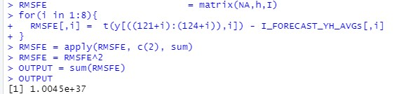

This is a clear indication that the model is not yet fully-refined and if not constrained by time it would be beneficial to seek out, and identify more appropriate variables to use in the forecast estimation of hours worked.